# 결측치·이상치 처리 실습 문제

- 전체 코드 표시
- 전체 코드 숨기기
- 소스 코드 표시

pandas의 apply·pipe·assign과 결측치/이상치 처리, Random Forest 기반 대체

공개

2026년 7월 19일

pandas의 핵심 메서드(`apply`, `pipe`, `assign`, `clip`)와 결측치·이상치 처리 기법을 직접 손으로 익히기 위한 문제 모음입니다.

| Part | 주제 |
| --- | --- |
| 1 | pandas 도구 다지기 — `axis`, `pipe`, `assign` |
| 2 | 결측치 처리 — 범주형/수치형 대체, 보간, 모델 기반 대체 |
| 3 | 이상치 처리 — IQR 판별, 제거, clipping |
| 4 | 심화 — Random Forest의 앙상블 효과 확인 |

각 문제를 먼저 스스로 풀어 본 뒤, 문제 아래의 **“정답 및 해설” 접힌 상자**를 열어 비교해 보세요. 외부 데이터 파일 없이 실행되도록 데이터는 코드로 생성합니다.

## Part 0. 준비 — 데이터 생성

아래 셀을 실행하면 세 가지 데이터가 만들어집니다. 문제를 풀기 전에 `info()`, `head()` 등으로 구조를 먼저 살펴보세요.

1. **`df_pass`** — 승객 정보 (범주형/수치형 혼합, `Age`·`Embarked`·`Deck`에 결측 존재)
2. **`s_rssi`** — 불규칙한 시점에 측정된 RSSI 신호 세기 (일부 결측). **인덱스가 등간격이 아닌** 시계열입니다.
3. **`df_field`** — 세 개의 연속형 변수 `fruitset`, `fruitmass`, `seeds` (일부 이상치 주입됨)

**코드**

```python
import pandas as pd
import numpy as np
import matplotlib.pyplot as plt

rng = np.random.default_rng(42)

# ------------------------------------------------------------
# 1) df_pass : 승객 데이터 (결측치 처리 실습용)
# ------------------------------------------------------------
n = 400
pclass = rng.choice([1, 2, 3], size=n, p=[0.25, 0.25, 0.5])
sex = rng.choice(['male', 'female'], size=n, p=[0.6, 0.4])

embarked = rng.choice(['S', 'C', 'Q'], size=n, p=[0.7, 0.2, 0.1]).astype(object)
embarked[rng.choice(n, size=4, replace=False)] = np.nan          # 결측 4건

# Age는 Pclass에 따라 분포가 다르도록 생성 (1등석일수록 나이가 많은 경향)
age = np.where(pclass == 1, rng.normal(42, 12, n),
      np.where(pclass == 2, rng.normal(32, 11, n),
                            rng.normal(26, 10, n))).clip(0.5, 80).round(1)
age = age.astype(float)
age[rng.choice(n, size=int(n * 0.2), replace=False)] = np.nan    # 결측 20%

sibsp = rng.poisson(0.5, n)
parch = rng.poisson(0.4, n)
fare = np.where(pclass == 1, rng.gamma(6, 12, n),
       np.where(pclass == 2, rng.gamma(4, 5, n),
                             rng.gamma(3, 3, n))).round(2)

# Deck은 Pclass별로 등장하는 범주가 다르고 결측이 많음 (60%)
deck = np.where(pclass == 1, rng.choice(list('ABC'), n),
       np.where(pclass == 2, rng.choice(list('DE'), n),
                             rng.choice(list('FG'), n))).astype(object)
deck[rng.choice(n, size=int(n * 0.6), replace=False)] = np.nan

df_pass = pd.DataFrame({
    'Pclass': pclass, 'Sex': sex, 'Age': age, 'SibSp': sibsp,
    'Parch': parch, 'Fare': fare, 'Embarked': embarked, 'Deck': deck
})
df_pass.index.name = 'PassengerId'

# ------------------------------------------------------------
# 2) s_rssi : 불규칙 샘플링된 RSSI 측정치 (보간 실습용)
#    - 인덱스: 측정 시각(초), 간격이 일정하지 않음
#    - 값: RSSI(dBm), 8개 결측
# ------------------------------------------------------------
t = np.sort(rng.choice(np.arange(0, 60, 0.5), size=40, replace=False))
rssi = -60 + 8 * np.sin(t / 8) + rng.normal(0, 1.2, size=len(t))
s_rssi = pd.Series(rssi.round(2), index=t, name='RSSI')
s_rssi.iloc[rng.choice(len(t), size=8, replace=False)] = np.nan

# ------------------------------------------------------------
# 3) df_field : 연속형 변수 3개 (이상치 실습용)
# ------------------------------------------------------------
m = 300
fruitset = rng.normal(0.5, 0.07, m)
fruitmass = 0.3 + 0.35 * fruitset + rng.normal(0, 0.02, m)
seeds = 10 + 45 * fruitset + rng.normal(0, 2, m)

out_idx = rng.choice(m, size=9, replace=False)                    # 이상치 주입
fruitset[out_idx[:3]] += rng.choice([-1, 1], 3) * rng.uniform(0.25, 0.4, 3)
fruitmass[out_idx[3:6]] += rng.uniform(0.15, 0.3, 3)
seeds[out_idx[6:]] -= rng.uniform(15, 25, 3)

df_field = pd.DataFrame({'fruitset': fruitset.round(4),
                         'fruitmass': fruitmass.round(4),
                         'seeds': seeds.round(2)})
df_field.index.name = 'Row'

df_pass.info()
```

```
<class 'pandas.DataFrame'>
RangeIndex: 400 entries, 0 to 399
Data columns (total 8 columns):
 #   Column    Non-Null Count  Dtype
---  ------    --------------  -----
 0   Pclass    400 non-null    int64
 1   Sex       400 non-null    str
 2   Age       320 non-null    float64
 3   SibSp     400 non-null    int64
 4   Parch     400 non-null    int64
 5   Fare      400 non-null    float64
 6   Embarked  396 non-null    str
 7   Deck      160 non-null    str
dtypes: float64(2), int64(3), str(3)
memory usage: 25.1 KB
```

**코드**

```python
# 데이터를 눈으로 확인해 봅니다.
display(df_pass.head())
display(s_rssi.head(8))
display(df_field.describe())
```

| PassengerId | Pclass | Sex | Age | SibSp | Parch | Fare | Embarked | Deck |
| --- | --- | --- | --- | --- | --- | --- | --- | --- |
| 0 | 3 | male | 21.7 | 0 | 0 | 5.23 | C | F |
| 1 | 2 | female | 14.5 | 1 | 0 | 7.11 | S | D |
| 2 | 3 | female | NaN | 0 | 0 | 7.74 | NaN | NaN |
| 3 | 3 | male | 22.9 | 2 | 1 | 18.82 | S | NaN |
| 4 | 1 | female | 40.6 | 0 | 2 | 145.19 | S | NaN |

```
1.5       NaN
2.5       NaN
6.5    -52.88
11.0   -53.06
11.5   -51.14
13.0   -52.48
15.5   -52.11
17.0   -53.75
Name: RSSI, dtype: float64
```

|  | fruitset | fruitmass | seeds |
| --- | --- | --- | --- |
| count | 300.000000 | 300.000000 | 300.00000 |
| mean | 0.501763 | 0.477818 | 32.23400 |
| std | 0.080177 | 0.039541 | 4.12994 |
| min | 0.055700 | 0.400000 | 11.45000 |
| 25% | 0.455050 | 0.455975 | 29.86750 |
| 50% | 0.498350 | 0.475750 | 32.08500 |
| 75% | 0.549425 | 0.496025 | 35.19500 |
| max | 0.929400 | 0.763000 | 42.82000 |

## Part 1. pandas 도구 다지기

### 문제 1-1. `axis` 예측하기

아래의 `df_toy`에 대해, **코드를 실행하기 전에** 네 줄의 출력 결과(값과 인덱스)를 종이에 먼저 적어 보세요. 그 다음 실행해서 확인합니다.

```python
df_toy = pd.DataFrame({'A': [1, 2, 3], 'B': [10, 20, 30], 'C': [100, 200, 300]},
                      index=['r1', 'r2', 'r3'])

(1) df_toy.sum(axis=0)
(2) df_toy.sum(axis=1)
(3) df_toy.apply(lambda x: x.max() - x.min(), axis=0)
(4) df_toy.apply(lambda x: x.max() - x.min(), axis=1)
```

추가 질문: (3)에서 람다 함수는 **총 몇 번 호출**될까요? (4)에서는 몇 번일까요?

**코드**

```python
df_toy = pd.DataFrame({'A': [1, 2, 3], 'B': [10, 20, 30], 'C': [100, 200, 300]},
                      index=['r1', 'r2', 'r3'])

# 예측을 먼저 적은 뒤, 여기에 네 줄을 실행해서 확인하세요.
```

**힌트정답 및 해설 1-1**

핵심: **`axis=k`는 “k번 축을 따라(그 축이 붕괴되도록)” 연산**한다는 뜻입니다.

- `(1) sum(axis=0)` — 행 축이 붕괴 → 세로로 더함 → **열별 합**: `A=6, B=60, C=600` (인덱스는 열 이름)
- `(2) sum(axis=1)` — 열 축이 붕괴 → 가로로 더함 → **행별 합**: `r1=111, r2=222, r3=333` (인덱스는 행 이름)
- `(3) apply(..., axis=0)` — 람다의 `x`에 **열**이 하나씩 → 열별 `max-min`: `A=2, B=20, C=200`. 열이 3개이므로 람다는 **3번** 호출됩니다.
- `(4) apply(..., axis=1)` — 람다의 `x`에 **행**이 하나씩 → 행별 `max-min`: `r1=99, r2=198, r3=297`. 행이 3개이므로 역시 **3번** 호출됩니다 (행 수가 크면 호출 수도 그만큼 커집니다).

“axis=1이니까 열에 적용”이라고 외우면 (3), (4)가 뒤집힙니다. **사라지는 축**으로 기억하세요.

**코드**

```python
display(df_toy.sum(axis=0))
display(df_toy.sum(axis=1))
display(df_toy.apply(lambda x: x.max() - x.min(), axis=0))
display(df_toy.apply(lambda x: x.max() - x.min(), axis=1))
```

```
A      6
B     60
C    600
dtype: int64
```

```
r1    111
r2    222
r3    333
dtype: int64
```

```
A      2
B     20
C    200
dtype: int64
```

```
r1     99
r2    198
r3    297
dtype: int64
```

### 문제 1-2. `pipe`로 중간 변수 없이 계산하기

“운임(`Fare`)이 중앙값보다 큰 승객들의 평균 나이”에서 “전체 승객의 평균 나이”를 뺀 값을 구하세요.

**조건**: 필터링된 DataFrame을 담는 중간 변수를 만들지 말고, `pipe`를 사용해 **하나의 체인**으로 작성하세요.

> 힌트: `df.loc[조건].pipe(lambda x: ...)` 패턴 — 필터링 결과가 `x`로 들어오므로 한 번만 필터링하면 됩니다.

**코드**

```python
# 여기에 작성하세요.
```

**힌트정답 및 해설 1-2**

`pipe(f)`는 `f(객체 전체)`와 같습니다. 필터링된 DataFrame이 `x`로 통째로 들어오므로, 중간 변수 없이 그 안에서 `Age` 평균을 꺼낼 수 있습니다. 람다는 정확히 **1번** 호출됩니다 (`apply`와의 결정적 차이).

**코드**

```python
df_pass.loc[df_pass['Fare'] > df_pass['Fare'].median()].pipe(
    lambda x: x['Age'].mean() - df_pass['Age'].mean()
)
```

```
np.float64(5.040547889610391)
```

양수가 나옵니다. 운임과 나이가 (Pclass를 매개로) 양의 상관을 갖도록 데이터를 생성했기 때문입니다. 참고로 `mean()`은 결측을 자동으로 제외하고 계산합니다(`skipna=True`가 기본값).

### 문제 1-3. `assign`으로 파생 변수 만들기

`df_pass`에 아래 세 개의 파생 변수를 **하나의 `assign` 호출**로 추가한 `df_a`를 만드세요. 원본 `df_pass`는 변경되지 않아야 합니다.

| 새 변수 | 정의 |
| --- | --- |
| `FamilySize` | `SibSp + Parch + 1` |
| `IsAlone` | `FamilySize == 1`이면 1, 아니면 0 (정수형) |
| `FarePerPerson` | `Fare / FamilySize` |

> 힌트: `IsAlone`과 `FarePerPerson`은 같은 호출 안에서 방금 만든 `FamilySize`를 참조해야 합니다. `assign`은 키워드 순서대로 평가된다는 점을 이용하세요.

작성 후 `'FamilySize' in df_pass.columns`가 `False`인지도 확인하세요.

**코드**

```python
# 여기에 작성하세요.
```

**힌트정답 및 해설 1-3**

`assign`은 **같은 호출 안에서도 키워드 순서대로 평가**되므로, 뒤의 람다가 앞에서 만든 열을 참조할 수 있습니다. 그리고 원본을 바꾸지 않고 새 DataFrame을 반환합니다.

**코드**

```python
df_a = df_pass.assign(
    FamilySize    = lambda x: x['SibSp'] + x['Parch'] + 1,
    IsAlone       = lambda x: (x['FamilySize'] == 1).astype(int),   # 방금 만든 열 참조
    FarePerPerson = lambda x: x['Fare'] / x['FamilySize']
)

display(df_a[['SibSp', 'Parch', 'FamilySize', 'IsAlone', 'FarePerPerson']].head())
print('원본에 FamilySize가 있는가?', 'FamilySize' in df_pass.columns)
```

| PassengerId | SibSp | Parch | FamilySize | IsAlone | FarePerPerson |
| --- | --- | --- | --- | --- | --- |
| 0 | 0 | 0 | 1 | 1 | 5.230000 |
| 1 | 1 | 0 | 2 | 0 | 3.555000 |
| 2 | 0 | 0 | 1 | 1 | 7.740000 |
| 3 | 2 | 1 | 4 | 0 | 4.705000 |
| 4 | 0 | 2 | 3 | 0 | 48.396667 |

```
원본에 FamilySize가 있는가? False
```

## Part 2. 결측치 처리

### 문제 2-1. 결측 현황 요약표 만들기

`df_pass`의 변수별 결측 개수(`n_missing`)와 결측 비율(`ratio`)을 담은 DataFrame을 만들고, 결측 개수 **내림차순**으로 정렬하세요.

**조건**: `isna()`, `sum()`, `to_frame()`, `assign()`, `sort_values()`를 체이닝으로 연결해 한 문장으로 작성하세요.

기대 형태:

```
          n_missing  ratio
Deck            ...    ...
Age             ...    ...
Embarked        ...    ...
...
```

> 생각해 볼 점: `df_pass.isna().sum()`에서 `sum()`은 `axis=0`과 `axis=1` 중 어느 쪽으로 동작하고 있나요? 그 결과 무엇이 세어지는 건가요?

**코드**

```python
# 여기에 작성하세요.
```

**힌트정답 및 해설 2-1**

`df_pass.isna()`는 같은 shape의 불리언 DataFrame이고, `sum()`의 기본값은 `axis=0`이므로 **세로 방향으로**(행 축이 붕괴되며) True(=1)를 세어 **열별 결측 개수**가 나옵니다. `to_frame('n_missing')`으로 Series를 DataFrame으로 바꾸면서 열 이름을 붙이고, `assign`으로 비율 열을 추가합니다.

**코드**

```python
df_pass.isna().sum().to_frame('n_missing').assign(
    ratio = lambda x: x['n_missing'] / len(df_pass)
).sort_values('n_missing', ascending=False)
```

|  | n_missing | ratio |
| --- | --- | --- |
| Deck | 240 | 0.60 |
| Age | 80 | 0.20 |
| Embarked | 4 | 0.01 |
| Pclass | 0 | 0.00 |
| SibSp | 0 | 0.00 |
| Sex | 0 | 0.00 |
| Fare | 0 | 0.00 |
| Parch | 0 | 0.00 |

### 문제 2-2. 결측을 새로운 범주로 대체

`df_pass`를 복사한 `df_p1`을 만들고, `Embarked`의 결측치를 `'Unk'` 범주로 대체하세요. 처리 후 `value_counts()`로 `'Unk'`가 4건인지 확인하세요.

**코드**

```python
# 여기에 작성하세요.
```

**힌트정답 및 해설 2-2**

결측 자체가 정보일 수 있으므로(예: 기록이 없다는 사실 자체가 특정 집단과 연관), 삭제하지 않고 `'Unk'`라는 범주로 보존하는 접근입니다.

**코드**

```python
df_p1 = df_pass.copy()
df_p1['Embarked'] = df_p1['Embarked'].fillna('Unk')
df_p1['Embarked'].value_counts()
```

```
Embarked
S      270
C       83
Q       43
Unk      4
Name: count, dtype: int64
```

### 문제 2-3. 그룹별 최빈값으로 대체

`df_p1`의 `Deck`은 결측이 매우 많고, `Pclass`별로 등장하는 범주가 다릅니다. 전체 최빈값 하나로 채우면 그룹 구조가 무너지므로, **각 `Pclass` 그룹 내부의 최빈값**으로 결측을 채우세요.

**조건**:

- `groupby('Pclass')` + `transform`을 사용하세요.
- 최빈값이 여러 개일 경우 **사전순으로 앞선 것**을 사용하세요 (`mode()`가 Series를 반환하는 이유를 생각해 보세요).

처리 후 두 가지를 확인하세요:

1. `Deck`의 결측이 0인가?
2. 각 `Pclass`별 최빈값이 무엇이었는가? (`groupby().agg()`로 확인)

**코드**

```python
# 여기에 작성하세요.
```

**힌트정답 및 해설 2-3**

두 가지 포인트:

1. **`mode()`는 Series를 반환**합니다 — 최빈값이 동수로 여러 개일 수 있기 때문입니다. 그래서 `sort_values().iloc[0]`으로 “사전순 첫 번째”를 결정적으로 뽑습니다. 이 처리가 없으면 동수 상황에서 결과가 모호해집니다.
2. **`transform` vs `agg`**: `agg`는 그룹당 값 1개로 **축약**하지만(그룹 수만큼의 결과), `transform`은 그 값을 그룹의 모든 행에 **브로드캐스트**해서 원본과 같은 길이의 결과를 돌려줍니다. 원본 열에 그대로 대입하려면 길이가 같아야 하므로 `transform`이 필요합니다.

**코드**

```python
df_p1['Deck'] = df_p1.groupby('Pclass')['Deck'].transform(
    lambda x: x.fillna(x.mode().sort_values().iloc[0])
)

print('남은 결측:', df_p1['Deck'].isna().sum())
print()
print('Pclass별 최빈값 (agg로 확인):')
display(df_p1.groupby('Pclass')['Deck'].agg(lambda x: x.mode().sort_values().iloc[0]))
display(pd.crosstab(df_p1['Pclass'], df_p1['Deck']))
```

```
남은 결측: 0

Pclass별 최빈값 (agg로 확인):
```

```
Pclass
1    B
2    D
3    G
Name: Deck, dtype: str
```

| Deck Pclass | A | B | C | D | E | F | G |
| --- | --- | --- | --- | --- | --- | --- | --- |
| 1 | 16 | 77 | 10 | 0 | 0 | 0 | 0 |
| 2 | 0 | 0 | 0 | 81 | 18 | 0 | 0 |
| 3 | 0 | 0 | 0 | 0 | 0 | 35 | 163 |

전체 최빈값 하나로 채웠다면 예컨대 3등석 승객에게 1등석에만 존재하는 Deck이 배정되는 왜곡이 생겼을 것입니다. 그룹별 대체는 조건부 분포 $P(\text{Deck} \mid \text{Pclass})$ 구조를 보존하는 방식입니다.

### 문제 2-4. 보간 — `linear` vs `index`

`s_rssi`는 **측정 간격이 불규칙한** 신호 세기 시계열입니다.

**(a)** `method='linear'`와 `method='index'`로 각각 보간한 결과를 구하고, 두 결과의 차이의 절대값이 **가장 큰 시점**과 그 차이를 출력하세요.

**(b)** `plt.subplots(1, 2, figsize=(12, 4))`로 1×2 subplot을 만들어 두 방식을 나란히 시각화하세요. 각 subplot에:

- 관측점(결측 아닌 값)들을 잇는 회색 선
- 관측점을 빨간 점으로
- 보간으로 **채워진 점만** 파란 점으로

을 그리고, 제목에 방식 이름을 표시하세요.

**(c)** 두 방식의 결과가 달라지는 이유를 한두 문장으로 적어 보세요. 이 데이터에는 어느 방식이 물리적으로 타당한가요?

> 힌트: `for method, ax in zip(['linear', 'index'], axes):` 구조를 쓰면 됩니다. 채워진 점만 골라내려면 `보간결과.loc[s_rssi.isna()]`. `subplots(1, 2)`의 반환값이 무엇인지, `figsize` 단위가 무엇인지도 함께 떠올려 보세요.

**코드**

```python
# (a) 여기에 작성하세요.
```

**코드**

```python
# (b) 여기에 작성하세요.
```

**힌트정답 및 해설 2-4**

**코드**

```python
# (a) 두 방식으로 보간하고 차이가 가장 큰 지점을 찾습니다.
v_linear = s_rssi.interpolate(method='linear')
v_index  = s_rssi.interpolate(method='index')

diff = (v_linear - v_index).abs()
print(f'최대 차이: {diff.max():.3f} dB  (t = {diff.idxmax()} s)')

# 결측이었던 지점만 나란히 비교
pd.DataFrame({'linear': v_linear, 'index': v_index, '|diff|': diff}).loc[s_rssi.isna()]
```

```
최대 차이: 1.254 dB  (t = 55.5 s)
```

|  | linear | index | \|diff\| |
| --- | --- | --- | --- |
| 1.5 | NaN | NaN | NaN |
| 2.5 | NaN | NaN | NaN |
| 31.5 | -65.7425 | -65.538333 | 0.204167 |
| 35.5 | -66.3550 | -67.171667 | 0.816667 |
| 36.0 | -66.9675 | -67.375833 | 0.408333 |
| 37.0 | -68.9750 | -68.975000 | 0.000000 |
| 55.5 | -54.3750 | -53.121429 | 1.253571 |
| 59.5 | -52.5200 | -52.520000 | 0.000000 |

**코드**

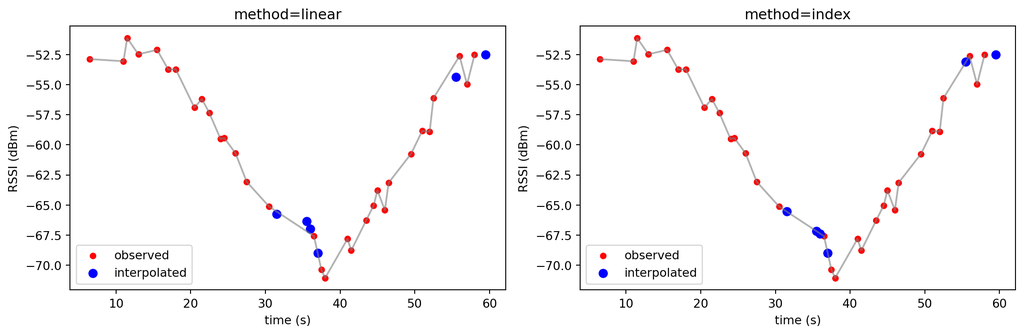

```python
# (b) 1x2 subplot으로 비교 시각화
# subplots(1, 2)의 반환값: (Figure, Axes 배열) 튜플. axes는 shape (2,)인 ndarray.
# figsize=(12, 4)의 단위: 인치. 기본 dpi=100이므로 1200x400 픽셀.
fig, axes = plt.subplots(1, 2, figsize=(12, 4))

for method, ax in zip(['linear', 'index'], axes):
    filled = s_rssi.interpolate(method=method)

    # 관측점을 잇는 선 (index 방식이 따라가는 기준선)
    ax.plot(s_rssi.loc[s_rssi.notna()], color='gray', alpha=0.6)

    # 관측점: pipe로 중간 변수 없이 index/values를 동시에 참조
    s_rssi.loc[s_rssi.notna()].pipe(
        lambda x: ax.scatter(x.index, x.values, color='red', s=20, label='observed')
    )
    # 보간으로 채워진 점만
    filled.loc[s_rssi.isna()].pipe(
        lambda x: ax.scatter(x.index, x.values, color='blue', s=45, label='interpolated')
    )
    ax.set_title(f'method={method}')
    ax.set_xlabel('time (s)')
    ax.set_ylabel('RSSI (dBm)')
    ax.legend()

plt.tight_layout()
plt.show()
```

**(c) 해설**

- `method='linear'`는 인덱스 값을 무시하고 **관측치들이 등간격이라고 가정**한 채 “몇 번째 위치인가”만으로 보간합니다. 반면 `method='index'`는 인덱스(측정 시각)를 실제 x좌표로 삼아 기하학적으로 올바른 선형 보간 $y = y_0 + (x - x_0)\frac{y_1 - y_0}{x_1 - x_0}$ 을 수행합니다.
- 이 데이터는 측정 간격이 불규칙하므로 두 방식의 결과가 달라지고, 시간 축이 물리적 의미를 갖는 이상 **`index` 방식이 타당**합니다. 결측 구간 앞뒤의 시간 간격이 비대칭일수록(예: 직전 관측 0.5초 전, 직후 관측 5초 뒤) `linear`의 왜곡이 커집니다.
- 인덱스가 `DatetimeIndex`라면 `method='time'`이 같은 역할을 합니다.

### 문제 2-5. 모델 기반 결측 대체 (Random Forest)

`df_pass`의 `Age` 결측(20%)을 Random Forest 회귀 모델의 예측값으로 대체하세요.

**절차**:

1. `df_pass`를 복사한 `df_p2`를 만들고, `Embarked` 결측은 최빈값으로 먼저 처리합니다.
2. `ColumnTransformer`를 구성합니다 — `Pclass`, `Sex`, `Embarked`는 `OneHotEncoder`, 나머지 입력(`SibSp`, `Parch`, `Fare`)은 `'passthrough'`.
3. `make_pipeline`으로 전처리와 `RandomForestRegressor(n_estimators=100, random_state=123)`를 묶습니다.
4. `Age`가 **관측된 행만으로** 학습하고, **결측인 행에만** 예측값을 채웁니다.

**추가 분석**: 대체 후 `Age`의 표준편차를 다음 세 경우로 비교하세요 — (i) 관측치만, (ii) 전체 평균으로 대체한 경우, (iii) RF로 대체한 경우. 어느 방식이 분산을 가장 심하게 축소시키나요? 왜 그럴까요?

> 힌트: 학습 단계는 `df_p2.loc[조건].pipe(lambda x: model.fit(x[X_cols], x['Age']))` 패턴을 쓰면 필터링을 한 번만 해도 됩니다.

**코드**

```python
from sklearn.pipeline import make_pipeline
from sklearn.compose import ColumnTransformer
from sklearn.preprocessing import OneHotEncoder
from sklearn.ensemble import RandomForestRegressor

# 여기에 작성하세요.
```

**힌트정답 및 해설 2-5**

**코드**

```python
# 1. 복사 후 Embarked를 최빈값으로 처리
df_p2 = df_pass.copy()
df_p2['Embarked'] = df_p2['Embarked'].fillna(df_p2['Embarked'].mode().iloc[0])

# 2~3. 전처리 + 모델 파이프라인
ct = ColumnTransformer([
    ('ohe', OneHotEncoder(), ['Pclass', 'Sex', 'Embarked']),   # 범주형 → 가변수
    ('pt', 'passthrough', ['SibSp', 'Parch', 'Fare'])          # 수치형 → 그대로
])
reg_rf = make_pipeline(ct, RandomForestRegressor(n_estimators=100, random_state=123))

X_cols = ['Pclass', 'Sex', 'Embarked', 'SibSp', 'Parch', 'Fare']

# 4. Age 관측 행으로 학습 → 결측 행에 예측값 대입
df_p2.loc[df_p2['Age'].notna()].pipe(
    lambda x: reg_rf.fit(x[X_cols], x['Age'])
)
df_p2.loc[df_p2['Age'].isna(), 'Age'] = \
    reg_rf.predict(df_p2.loc[df_p2['Age'].isna(), X_cols])

print('대체 후 Age 결측:', df_p2['Age'].isna().sum())
```

```
대체 후 Age 결측: 0
```

**코드**

```python
# 추가 분석: 세 경우의 표준편차 비교
std_obs  = df_pass['Age'].std()                                  # (i) 관측치만
std_mean = df_pass['Age'].fillna(df_pass['Age'].mean()).std()    # (ii) 평균 대체
std_rf   = df_p2['Age'].std()                                    # (iii) RF 대체

pd.Series({'관측치만': std_obs, '평균 대체': std_mean, 'RF 대체': std_rf},
          name='Age std').round(3).to_frame()
```

|  | Age std |
| --- | --- |
| 관측치만 | 12.296 |
| 평균 대체 | 10.994 |
| RF 대체 | 11.494 |

**해설**

- **평균 대체**가 분산을 가장 크게 축소합니다. 결측 20%를 전부 분포의 무게중심 한 점에 몰아넣기 때문입니다. 관측 비율을 $p$라 하면 대체 후 분산은 대략 $p \cdot \sigma^2$ 수준으로 줄어듭니다.
- **RF 대체**는 조건부 기대값 $E[\text{Age} \mid \text{Pclass}, \text{Sex}, \dots]$ 를 근사하므로 채워진 값들이 여러 위치에 퍼져 분산 축소가 덜합니다. 다만 조건부 평균 근처로 수축하는 성질은 남아 있어 관측치만의 표준편차보다는 여전히 작습니다.
- 어떤 단일값 대체(single imputation)도 “대체값이 불확실하다”는 정보는 반영하지 못합니다. 이후 추론(신뢰구간, 가설검정)이 중요하다면 다중 대체(multiple imputation)처럼 불확실성을 명시적으로 다루는 방법을 고려해야 합니다.

## Part 3. 이상치 처리

### 문제 3-1. IQR 경계 테이블 만들기

`df_field`의 세 변수에 대해, 아래 형태의 경계 테이블 `df_iqr`을 **하나의 체인**(`apply` → `.T` → `assign`)으로 만드세요.

```
                 Q1        Q3       IQR        LB        UB
fruitset        ...       ...       ...       ...       ...
fruitmass       ...       ...       ...       ...       ...
seeds           ...       ...       ...       ...       ...
```

- $\mathrm{IQR} = Q_3 - Q_1$
- $\mathrm{LB} = Q_1 - 1.5 \times \mathrm{IQR}$, $\mathrm{UB} = Q_3 + 1.5 \times \mathrm{IQR}$

> 생각해 볼 점: `apply` 직후 결과에서 변수명은 행과 열 중 어디에 있나요? `.T`가 필요한 이유는 이후 어떤 조회 패턴을 위해서인가요?

**코드**

```python
# 여기에 작성하세요.
```

**힌트정답 및 해설 3-1**

**코드**

```python
cols = ['fruitset', 'fruitmass', 'seeds']

df_iqr = df_field[cols].apply(
    lambda x: x.quantile([0.25, 0.75]).rename({0.25: 'Q1', 0.75: 'Q3'})
).T.assign(
    IQR = lambda x: x['Q3'] - x['Q1'],
    LB  = lambda x: x['Q1'] - 1.5 * x['IQR'],   # 같은 assign 안에서 IQR 참조 가능
    UB  = lambda x: x['Q3'] + 1.5 * x['IQR']
)
df_iqr
```

|  | Q1 | Q3 | IQR | LB | UB |
| --- | --- | --- | --- | --- | --- |
| fruitset | 0.455050 | 0.549425 | 0.094375 | 0.313487 | 0.690988 |
| fruitmass | 0.455975 | 0.496025 | 0.040050 | 0.395900 | 0.556100 |
| seeds | 29.867500 | 35.195000 | 5.327500 | 21.876250 | 43.186250 |

**해설**

- `apply(axis=0)` 직후에는 변수명이 **열**, 통계량(Q1/Q3)이 **행**에 있습니다. `.T`로 뒤집어 변수명을 행 인덱스로 놓는 이유는, 다음 문제에서 `df_iqr.loc[변수명, 'LB']` 형태의 **룩업**을 하기 위한 사전 설계입니다.
- `assign`은 키워드 순서대로 평가되므로 `LB`, `UB`가 같은 호출 안에서 방금 만든 `IQR`을 참조할 수 있습니다.
- 참고: 정규분포 가정 하에서 $Q_3 + 1.5 \cdot \mathrm{IQR}$은 약 $\mu + 2.7\sigma$에 해당하며, 전체의 약 0.7%만 경계 밖에 놓이는 보수적 기준입니다. 사분위수는 극단값에 오염되지 않는 로버스트 통계량이라는 점이 평균·표준편차 기반 기준 대비 장점입니다.

### 문제 3-2. 이상치 제거

**(a)** 각 셀이 이상치인지 여부(True/False)를 담은 `df_is_out`을 만드세요. `apply`와 `x.name`을 활용해 변수별로 서로 다른 경계를 `df_iqr`에서 조회해야 합니다.

**(b)** 변수별 이상치 개수와, **하나라도 이상치인 행**의 개수를 출력하세요. 후자에는 `any`를 쓰되, `axis` 값을 무엇으로 해야 하는지 근거와 함께 정하세요.

**(c)** 이상치가 하나라도 있는 행을 제거한 `df_field2`를 만들고 shape를 확인하세요.

**코드**

```python
# 여기에 작성하세요.
```

**힌트정답 및 해설 3-2**

**코드**

```python
# (a) 셀 단위 이상치 판별
# apply(axis=0)로 열이 하나씩 들어오고, x.name에 열 이름이 담겨 있으므로
# 변수별로 서로 다른 경계를 df_iqr에서 조회할 수 있습니다.
df_is_out = df_field[cols].apply(
    lambda x: (x < df_iqr.loc[x.name, 'LB']) | (x > df_iqr.loc[x.name, 'UB'])
)

# (b) 변수별 개수(세로로 셈 → axis=0), 행 단위 판정(가로로 봄 → axis=1)
print('변수별 이상치 수:')
display(df_is_out.sum(axis=0))

n_rows = df_is_out.any(axis=1).sum()
print(f'하나라도 이상치인 행: {n_rows}건')
display(df_field.loc[df_is_out.any(axis=1)])
```

```
변수별 이상치 수:
```

```
fruitset     4
fruitmass    5
seeds        3
dtype: int64
```

```
하나라도 이상치인 행: 12건
```

| Row | fruitset | fruitmass | seeds |
| --- | --- | --- | --- |
| 21 | 0.9294 | 0.5018 | 36.90 |
| 29 | 0.5085 | 0.4794 | 13.13 |
| 49 | 0.0557 | 0.4559 | 24.32 |
| 62 | 0.5480 | 0.6541 | 35.26 |
| 107 | 0.5435 | 0.4758 | 21.47 |
| 118 | 0.6678 | 0.5710 | 42.58 |
| 154 | 0.4467 | 0.4555 | 11.45 |
| 181 | 0.6176 | 0.5660 | 34.10 |
| 204 | 0.1801 | 0.5011 | 36.60 |
| 215 | 0.5307 | 0.7630 | 36.03 |
| 285 | 0.6755 | 0.7444 | 38.44 |
| 288 | 0.7306 | 0.5408 | 42.82 |

**코드**

```python
# (c) 이상치 행 제거
df_field2 = df_field.drop(index=df_field.loc[df_is_out.any(axis=1)].index)
print('제거 전:', df_field.shape, '→ 제거 후:', df_field2.shape)
```

```
제거 전: (300, 3) → 제거 후: (288, 3)
```

**`any(axis=1)`인 이유**: “한 **행** 안에서 세 변수 중 하나라도 True인가”를 물으려면, **열 축을 따라(가로로)** 훑으며 열 축이 붕괴되어야 합니다. 결과는 행 개수만큼의 불리언 Series가 되고, 이것이 행 필터로 쓰입니다. `any(axis=0)`이었다면 “각 변수에 이상치가 하나라도 있는가”라는 변수별 답(길이 3)이 나왔을 것입니다.

또한 `drop(axis=...)` 계열의 구조 조작에서는 axis가 “대상 축”(`axis=0`이면 행 삭제)이라는 직관적 의미로 쓰인다는 점도 함께 기억해 두세요 — 집계 연산의 “붕괴되는 축”과 뉘앙스가 다릅니다.

### 문제 3-3. 범위 한정 (clipping)

`df_field`를 복사한 `df_field3`을 만들고, 세 변수를 각 변수의 `[LB, UB]` 구간으로 clip 하세요.

**조건**: `apply` 한 번으로 세 변수를 동시에 처리하세요. 람다 안에서 `x.name`으로 `df_iqr`의 해당 행을 조회합니다.

**검증**: clip 후 데이터에 문제 3-2의 이상치 판별을 다시 적용했을 때 이상치가 **0건**이어야 합니다.

**코드**

```python
# 여기에 작성하세요.
```

**힌트정답 및 해설 3-3**

**코드**

```python
df_field3 = df_field.copy()

df_field3[cols] = df_field3[cols].apply(
    lambda x: x.clip(df_iqr.loc[x.name, 'LB'], df_iqr.loc[x.name, 'UB'])
)

# 검증: clip 후에는 이상치가 0건이어야 합니다.
n_out_after = df_field3[cols].apply(
    lambda x: (x < df_iqr.loc[x.name, 'LB']) | (x > df_iqr.loc[x.name, 'UB'])
).sum().sum()
print('clip 후 이상치 수:', n_out_after)

df_field3[cols].agg(['min', 'max'])
```

```
clip 후 이상치 수: 0
```

|  | fruitset | fruitmass | seeds |
| --- | --- | --- | --- |
| min | 0.313487 | 0.4000 | 21.87625 |
| max | 0.690988 | 0.5561 | 42.82000 |

`clip(L, U)`는 $\min(\max(x, L), U)$ — 구간 밖의 값을 경계로 밀어 넣는 포화(saturation) 연산입니다. 판별(3-2)과 동일하게 `x.name`으로 변수별 경계를 룩업하므로, 변수가 늘어나도 코드는 그대로입니다. 경계 계산(`df_iqr`)과 적용(clip)이 분리되어 있어서, 예컨대 학습 데이터에서 구한 경계를 나중에 테스트 데이터에 그대로 적용하는 재사용도 자연스럽습니다.

### 문제 3-4. 제거 vs clip — 통계량 비교

원본 `df_field`, 제거본 `df_field2`, clip본 `df_field3` 세 데이터의 변수별 **평균과 표준편차**를 한 표로 모아 비교하세요 (`pd.concat`에 dict를 넘기면 계층 인덱스로 묶을 수 있습니다).

그리고 다음 질문에 답해 보세요:

1. 표준편차는 어느 처리에서 더 많이 줄어들었나요?
2. 표본 크기 관점에서 두 방식의 차이는 무엇인가요?
3. 만약 이 이상치들이 측정 오류가 아니라 실제 현상(예: heavy-tailed 분포의 꼬리)이라면, 두 방식 모두 어떤 문제를 일으킬까요?

**코드**

```python
# 여기에 작성하세요.
```

**힌트정답 및 해설 3-4**

**코드**

```python
pd.concat({
    'original': df_field[cols].agg(['mean', 'std']),
    'removed':  df_field2[cols].agg(['mean', 'std']),
    'clipped':  df_field3[cols].agg(['mean', 'std'])
}).round(4)
```

|  |  | fruitset | fruitmass | seeds |
| --- | --- | --- | --- | --- |
| original | mean | 0.5018 | 0.4778 | 32.2340 |
|  | std | 0.0802 | 0.0395 | 4.1299 |
| removed | mean | 0.5003 | 0.4744 | 32.2816 |
|  | std | 0.0674 | 0.0300 | 3.6379 |
| clipped | mean | 0.5021 | 0.4761 | 32.2993 |
|  | std | 0.0715 | 0.0315 | 3.8827 |

**해설**

1. **표준편차 감소는 제거(removed) 쪽이 더 큽니다.** 제거는 극단값을 완전히 없애지만, clip은 그 관측치를 경계값 위치에 남겨두기 때문입니다. 두 경우 모두 원본보다 작아지는데, 이상치가 분산에 기여하던 몫이 사라지거나 줄어든 결과입니다.
2. **표본 크기**: 제거는 행 자체를 버리므로 $n$이 줄고, 그 행의 **다른 변수 값들까지 함께 손실**됩니다 (한 변수만 이상해도 행 전체가 사라짐). clip은 $n$을 보존하면서 극단값의 지렛대 효과만 제한합니다 — 통계에서 윈저라이징(winsorizing)이라 부르는 방식입니다.
3. **진짜 신호였다면**: 두 방식 모두 분포의 꼬리를 인위적으로 잘라내므로, heavy tail 자체가 관심 대상인 문제(예: 드물지만 깊은 신호 감쇠 이벤트, 극단적 지연)에서는 핵심 정보를 파괴합니다. clip은 추가로 경계값 한 점에 질량이 뭉치는 왜곡도 만듭니다. 이상치 처리는 항상 “오류인가, 현상인가”라는 도메인 판단이 선행되어야 합니다.

## Part 4. 심화 — 앙상블은 정말 분산을 줄이는가

Random Forest의 핵심 원리는 “상관이 낮은 고분산 추정기들을 평균 내면 분산이 줄어든다”는 것입니다:

$$\mathrm{Var}\left(\frac{1}{B}\sum_b \hat f_b\right) = \rho\sigma^2 + \frac{1-\rho}{B}\sigma^2$$

### 문제 4-1. 나무 수 $B$와 예측의 안정성

이를 실험으로 확인합니다. `Age`가 관측된 행들을 학습/평가 세트로 나눈 뒤:

1. `n_estimators` $B \in \{1, 5, 25, 100\}$ 각각에 대해,
2. `random_state`를 0~4로 바꿔가며 5개의 모델을 학습시키고 평가 세트를 예측합니다.
3. 각 평가 샘플에 대해 **5개 시드 간 예측값의 표준편차**를 구하고, 그 평균을 $B$별로 비교하세요.

$B$가 커질수록 시드 간 예측 편차(= 모델의 무작위성에 의한 분산)가 줄어드는지, 줄어드는 속도가 $1/B$ 꼴에 가까운지 관찰해 보세요.

> 힌트: 예측값들을 `np.array`로 쌓으면(shape: 5 × 평가샘플수) `np.std(arr, axis=0)`이 샘플별 시드 간 표준편차입니다. 이때 왜 `axis=0`인지도 설명할 수 있어야 합니다.

**코드**

```python
from sklearn.model_selection import train_test_split

# 여기에 작성하세요.
```

**힌트정답 및 해설 4-1**

**코드**

```python
# Age가 관측된 행만 사용 (Embarked는 이미 처리된 df_p2 이용)
df_obs = df_p2.loc[df_pass['Age'].notna()]
tr, te = train_test_split(df_obs, test_size=0.3, random_state=0)

result = {}
for B in [1, 5, 25, 100]:
    preds = []
    for seed in range(5):
        model = make_pipeline(
            ColumnTransformer([
                ('ohe', OneHotEncoder(), ['Pclass', 'Sex', 'Embarked']),
                ('pt', 'passthrough', ['SibSp', 'Parch', 'Fare'])
            ]),
            RandomForestRegressor(n_estimators=B, random_state=seed)
        )
        model.fit(tr[X_cols], tr['Age'])
        preds.append(model.predict(te[X_cols]))

    preds = np.array(preds)              # shape: (5개 시드, 평가샘플 수)
    # axis=0: "시드 축"이 붕괴 → 평가샘플별 시드 간 표준편차
    result[B] = np.std(preds, axis=0).mean()

pd.Series(result, name='시드 간 예측 표준편차(평균)').round(3).to_frame()
```

|  | 시드 간 예측 표준편차(평균) |
| --- | --- |
| 1 | 7.386 |
| 5 | 3.567 |
| 25 | 1.605 |
| 100 | 0.899 |

**코드**

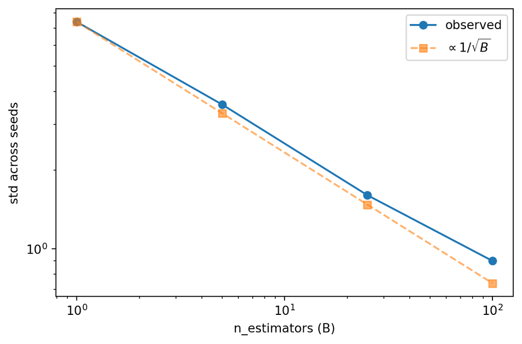

```python
# 감소 추세를 시각화하고 1/sqrt(B) 스케일과 비교합니다.
# (독립 평균의 표준편차는 1/sqrt(B)에 비례: Var가 1/B로 줄면 std는 1/sqrt(B))
fig, ax = plt.subplots(figsize=(6, 4))
Bs = np.array(list(result.keys()))
stds = np.array(list(result.values()))

ax.plot(Bs, stds, 'o-', label='observed')
ax.plot(Bs, stds[0] / np.sqrt(Bs), 's--', alpha=0.6, label=r'$\propto 1/\sqrt{B}$')
ax.set_xscale('log'); ax.set_yscale('log')
ax.set_xlabel('n_estimators (B)')
ax.set_ylabel('std across seeds')
ax.legend()
plt.tight_layout()
plt.show()
```

**해설**

- $B$가 커질수록 시드 간 예측 편차가 뚜렷하게 감소합니다 — 나무 하나($B=1$)는 학습 데이터의 무작위성에 매우 민감하지만, 평균을 내면 그 요동이 상쇄됩니다.
- 분산 공식 $\rho\sigma^2 + \frac{1-\rho}{B}\sigma^2$에서 두 번째 항이 $1/B$로 줄어드는 부분입니다 (표준편차 기준으로는 $1/\sqrt{B}$). log-log 그림에서 관측 곡선이 $1/\sqrt{B}$ 기울기와 유사하게 내려가는 것을 확인할 수 있습니다. 다만 나무들 사이의 상관 $\rho$ 때문에 첫 번째 항 $\rho\sigma^2$는 남고, 여기서 측정한 “시드 간 편차”가 0으로 수렴하더라도 **앙상블 전체의 예측 분산에는 $\rho\sigma^2$ 바닥이 존재**합니다. 그래서 부트스트랩과 분할 시 무작위 특성 선택으로 $\rho$를 낮추는 것이 Random Forest 설계의 핵심입니다.
- `np.std(preds, axis=0)`에서 `axis=0`인 이유: `preds`의 shape는 (시드 5, 샘플 수)이고, 우리가 원하는 것은 **샘플별로** 시드 축이 붕괴된 표준편차이기 때문입니다. `axis=1`로 했다면 “시드별로 샘플 간 표준편차”라는 전혀 다른 양이 나옵니다 — Part 1에서 다진 axis 감각이 그대로 쓰이는 지점입니다.

## 마무리 체크리스트

- `axis=k`는 “k번 축이 붕괴”로 기억한다. 단, `drop`/`concat` 등 구조 조작에서는 “대상 축”이다.
- `pipe` = 객체 전체를 함수에 1회 전달 / `apply` = 조각(원소·행·열)마다 반복 호출 / `assign` = 파생 열 추가 후 DataFrame 반환.
- `apply(axis=0)`에서 람다로 들어온 Series의 `.name`에는 열 이름이 있다 → 룩업 테이블(`df_iqr.loc[x.name, ...]`) 패턴.
- `mode()`는 동수 가능성 때문에 Series를 반환한다. 결정적 선택 규칙(`sort_values().iloc[0]`)을 명시할 것.
- `transform`은 원본 길이를 보존하므로 대입에 쓰고, `agg`는 그룹당 1개로 축약한다.
- 인덱스가 물리적 축(시간·거리)이면 보간은 `method='index'`(또는 `'time'`). 기본값 `'linear'`는 등간격 가정.
- 단일값 대체는 분산을 축소한다 (평균 대체 ≫ 모델 기반 대체). 불확실성 반영이 필요하면 다중 대체.
- 이상치 제거는 $n$과 다른 변수 정보를 잃고, clip(윈저라이징)은 $n$을 보존하되 경계에 질량이 뭉친다. 어느 쪽이든 “오류 vs 현상” 판단이 먼저다.
- 앙상블 평균의 분산은 $\rho\sigma^2 + \frac{1-\rho}{B}\sigma^2$ — 나무 수를 늘리는 것만으로는 $\rho\sigma^2$ 바닥을 못 넘는다.